# Bath Spectral Density

## Hamiltonian

Lets consider a system with a non-specified free hamiltonian $\hat{H}_S$ interacting with a bosonic bath of free hamiltonian $\hat{H}_B = \sum_k \omega_k \hat{a}^\dagger_k\hat{a}_k$ through an interaction hamiltonian linear in bath operators $\hat{H}_{\text{int}} = \hat{O}\sum_k ( g_k\hat{a}_k + \text{h.c.})$.

The evolution of the full density matrix is given by the von Neumann Master equation: $$\frac{\mathrm{d}}{\mathrm{d}t}\hat{\rho} = -\frac{\mathrm{i}}{\hbar}\left[\hat{H}_\text{int}, \hat{\rho}\right] \overset{\text{def.}}{=} \mathcal{L}\hat{\rho}$$ where $\mathcal{L}$ is a super-operator.

An equation of evolution for the system density matrix $\hat{\rho}_S$ can be obtained by tracing out the bath degrees of freedom: $$\frac{\mathrm{d}}{\mathrm{d}t}\hat{\rho}_S = -\frac{\mathrm{i}}{\hbar}\mathrm{tr}\left[\mathcal{L}\hat{\rho}\right]$$

After some manipulations and simplifications: $$ \hat{\rho}_S(t) = \overset{\gets}{T_S}\exp\left(\int_{t_0}^t \int_{t_0}^{t'} \mathrm{d} t'\mathrm{d} t'' \left\langle\mathcal{L}^I(t')\mathcal{L}^I(t'')\right\rangle_B\right)\hat{\rho}_S(t_0) $$

## Bath Correlation Function

$$C(\tau) = \int_0^{\infty} \mathrm{d}\omega J(\omega)\left[\coth\left(\frac{\hbar\omega}{2k_BT}\right)\cos\left(\omega\tau\right) - \mathrm{i}\sin\left(\omega\tau\right)\right]$$

with the bath spectral density $J(\omega) = \sum_i |g_i|^2\delta(\omega - \omega_i) \text{ where } \omega \geq 0$

We can already see that for different spectral densities $J(\omega)$ the bath correlation function is going to have different behaviours, and especially different timescales for the bath correlation time $\tau_B$.

If all the bath modes couple to the bath the same way, *i.e.* $J(\omega) = J_0$, at zero temperature the correlation function is a Dirac delta function. Thus there are only instantaneous correlations into the bath. It is a limit case of what is called a Markovian behaviour.

```python
from numpy import exp, cos, sin, tanh, sinc, absolute, pi, arange
import matplotlib.pyplot as plt
from matplotlib import rc
rc('text', usetex=False)
```

## Flat Spectral Density

$$C(\tau) = J_0 \Delta\omega \text{sinc}(\frac{\Delta\omega\tau}{2})\exp(-\mathrm{i}\omega_0\tau) $$

The characteristic correlation time of the bath correlation function (corresponding to the first zero of the $\text{sinc}$) is : $\tau_B = \frac{2\pi}{\Delta\omega}$.

Note that $\lim_{\Delta\omega \to \infty} C(t) = \delta(t)$.

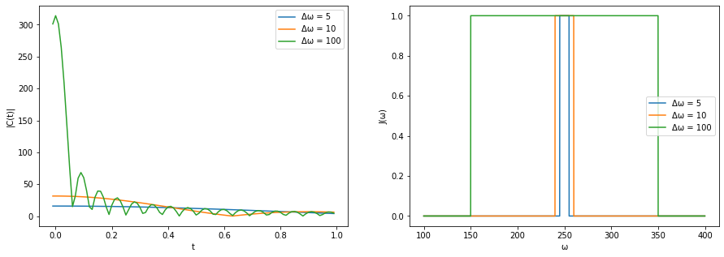

```python
f = plt.figure(figsize=(15,5))
ax1 = f.add_subplot(121, xlabel="t", ylabel="|C(t)|")
ax2 = f.add_subplot(122, xlabel="ω",ylabel="J(ω)")


J0 = 1
C = []
t = arange(-0.01,1,0.01)
DeltaOmega = [5,10,100]
legend = []

for Dw in DeltaOmega:
    C = J0*Dw*pi*absolute(sinc(Dw*t/(2*pi)))
    ax1.plot(t,C)
    legend.append(r'Δω = {}'.format(Dw))
ax1.legend(legend)


J = []
omega = arange(100,400,0.1)
omega0 = 250

for Dw in DeltaOmega:
    J = [J0*int(om <= (omega0+Dw) and om >= (omega0-Dw)) for om in omega]
    ax2.plot(omega,J)
    legend.append(r'Δω = {}'.format(Dw))
ax2.legend(legend)


plt.show()
```

## Lorentzian Spectral Density

The Lorentzian Spectral Density is peaked around a specific angular frequency $\omega_0$ amd has a bandwidth $\alpha$.

$$ J(\omega) = \frac{\alpha^2 J_0}{(\omega - \omega_0)^2 + \alpha^2}$$$$ C(\tau) = \pi\alpha J_0 \exp(-\alpha\tau)\exp(-\mathrm{i}\omega_0\tau) $$

If the bandwidth is narrow only a few frequencies are selected and the correlation function has a large correlation time, with the limit case of the Dirac delat spectral density leading to an flat correlation function (*i.e.* a infinite correlation time).

On the other hand, the larger the bandwith, the flatter the spectral density and the more peaked the correlation function.

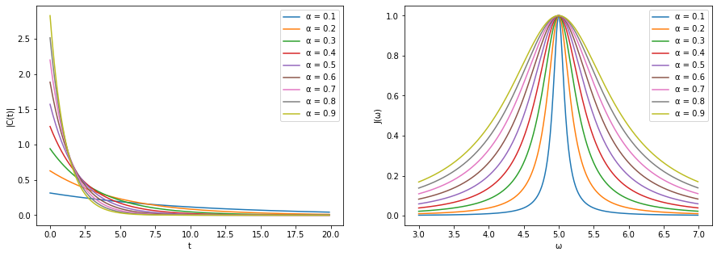

```python
f = plt.figure(figsize=(15,5))
ax1 = f.add_subplot(121, xlabel="t", ylabel="|C(t)|")
ax2 = f.add_subplot(122, xlabel="ω",ylabel="J(ω)")

J0 = 1
C = []
t = arange(0,20,0.1)

legend = []
for alpha10 in range(1,10):
    C = J0*pi*alpha10/10*exp(-alpha10/10*t)
    ax1.plot(t,C)
    legend.append(r'α = {}'.format(alpha10/10))
ax1.legend(legend)

J = []
omega = arange(3,7,0.01)
omega0 = 5


for alpha10 in range(1,10):
    J = alpha10**2/100*J0/((omega-omega0)**2 + (alpha10/10)**2)
    ax2.plot(omega,J)
ax2.legend(legend)
plt.show()
```